# Домашняя работа.

Яна Кокорева

14/III/2022

- вариант 2
- [ссылка](https://yanakoko.github.io/) на html-страницу

## Загрузка нужных библиотек

```r
library(tidyverse)
```

```r
library(ggplot2)
library(nortest)
library(CGPfunctions)
```

## Читаем файлы

```r
my_data <- read_tsv('C:/HSE/3 курс/R/data_exp2.csv')
word_info <- read_tsv('C:/HSE/3 курс/R/word_info.csv')
head(my_data)
```

```
## # A tibble: 6 x 10
##   key_pressed   acc    RT word    prime   corrAns participant  order trial cond
##   <chr>       <dbl> <dbl> <chr>   <chr>   <chr>   <chr>        <dbl> <dbl> <chr>
## 1 l               1 0.732 ГРУДЬ   СHEST   l       Miloslava O~     0    89 CS
## 2 a               1 0.72  КОЛЬВАМ ЦЕРКОВЬ a       Miloslava O~     1   181 PW
## 3 a               1 0.673 ФЕФЕР   ЗАМОК   a       Miloslava O~     2   150 PW
## 4 a               1 0.787 ПЕСПОДЬ УСЛОВИЕ a       Miloslava O~     3   179 PW
## 5 l               1 0.599 ТРУД    WORK    l       Miloslava O~     5    68 CS
## 6 a               1 0.698 ВЕЛЮР   BERRY   l       Miloslava O~     6     1 ORTH
```

```r
head(word_info)
```

```
## # A tibble: 6 x 10
##   word   prime  trial cond  word_len prime_len word_freq word_freqlgl prime_freq
##   <chr>  <chr>  <dbl> <chr>    <dbl>     <dbl>     <dbl>        <dbl>      <dbl>
## 1 АВГУСТ ABROAD     6 ORTH         6         6      91         1.96         4.9
## 2 АСБЕСТ ACROSS     7 ORTH         6         6       1.2       0.0792      94.1
## 3 КЛУБ   AIDE     244 CTRL         4         4     103         2.01         2.02
## 4 АРБУЗ  APRON      8 ORTH         5         5       9.1       0.959        2.67
## 5 ВАГОН  BADGE      9 ORTH         5         5      70.9       1.85        15.2
## 6 ВАЛЕТ  BAGEL     10 ORTH         5         5       2.3       0.362        3.06
## # ... with 1 more variable: prime_freqlg <dbl>
```

```r
summary(my_data)
```

```
##  key_pressed             acc               RT                word
##  Length:5430        Min.   :0.0000   Min.   :  0.09024   Length:5430
##  Class :character   1st Qu.:1.0000   1st Qu.:  0.59693   Class :character
##  Mode  :character   Median :1.0000   Median :  0.68846   Mode  :character
##                     Mean   :0.9589   Mean   :  0.80979
##                     3rd Qu.:1.0000   3rd Qu.:  0.82716
##                     Max.   :1.0000   Max.   :196.97302
##     prime             corrAns          participant            order
##  Length:5430        Length:5430        Length:5430        Min.   :  0.0
##  Class :character   Class :character   Class :character   1st Qu.: 67.0
##  Mode  :character   Mode  :character   Mode  :character   Median :135.0
##                                                           Mean   :134.5
##                                                           3rd Qu.:202.0
##                                                           Max.   :269.0
##      trial           cond
##  Min.   :  0.0   Length:5430
##  1st Qu.: 67.0   Class :character
##  Median :135.0   Mode  :character
##  Mean   :135.2
##  3rd Qu.:203.0
##  Max.   :269.0
```

`my_data` содержит 10 разных переменных, среди них есть как строковые (`key_pressed`, `word`, `prime`, `corrAns`, `participant`, `cond`), так и числовые.

```r
summary(word_info)
```

```
##      word              prime               trial            cond
##  Length:270         Length:270         Min.   :  0.00   Length:270
##  Class :character   Class :character   1st Qu.: 67.25   Class :character
##  Mode  :character   Mode  :character   Median :134.50   Mode  :character
##                                        Mean   :134.50
##                                        3rd Qu.:201.75
##                                        Max.   :269.00
##     word_len       prime_len       word_freq        word_freqlgl
##  Min.   :4.000   Min.   :4.000   Min.   :   0.00   Min.   :-0.2218
##  1st Qu.:4.000   1st Qu.:4.250   1st Qu.:   0.00   1st Qu.: 0.0000
##  Median :5.000   Median :5.000   Median :   3.05   Median : 0.4814
##  Mean   :5.341   Mean   :5.407   Mean   :  76.97   Mean   : 0.9460
##  3rd Qu.:6.000   3rd Qu.:6.000   3rd Qu.:  90.47   3rd Qu.: 1.9565
##  Max.   :8.000   Max.   :8.000   Max.   :1200.60   Max.   : 3.0794
##    prime_freq       prime_freqlg
##  Min.   :   0.12   Min.   :-0.9208
##  1st Qu.:  19.80   1st Qu.: 1.2967
##  Median :  93.75   Median : 1.9720
##  Mean   : 199.90   Mean   : 1.7235
##  3rd Qu.: 169.47   3rd Qu.: 2.2291
##  Max.   :8561.00   Max.   : 3.9325
```

`word_info` содержит 10 разных переменных, среди них есть как строковые (`word`, `prime`, `cond`), так и числовые (все прочие).

# Чистка данных

## Проверяем, есть ли участники с аккуратностью меньше 80%

поскольку в колонке `acc` не всегда стоит 1, если нажатая клавиша совпадает с правильным ответом, то приходится сначала сделать лишнюю колонку, которой впоследствии и пользоваться.

```r
my_data %>%
  mutate(correct = ifelse(key_pressed == corrAns, 1, 0)) -> my_new_data

my_new_data %>%
  group_by(participant) %>%
    summarize(sum = sum(correct), mean = sum/269) %>%
  filter(mean <= 0.8)
```

```
## # A tibble: 1 x 3
##   participant      sum  mean
##   <chr>          <dbl> <dbl>
## 1 Angelina Jo Li    30 0.112
```

Это `Angelina Jo Li`, убираем её отвтеы:

```r
my_clean_data <- my_new_data %>%
  filter(participant != 'Angelina Jo Li')
```

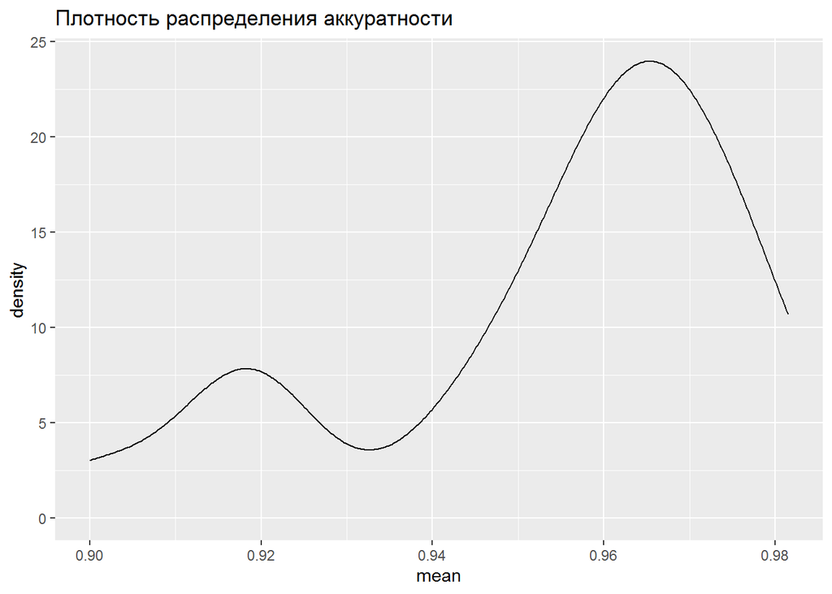

```r
my_clean_data %>%
  group_by(participant) %>%
  summarize(mean = mean(correct)) %>%
  select(mean) -> m

ggplot(data = m, aes(x = mean))+
geom_density()+
  labs(title = 'Плотность распределения аккуратности')
```

время реакции

```r
my_clean_data %>%
  filter(RT > 0.2&RT < 1.15) -> clean_data
```

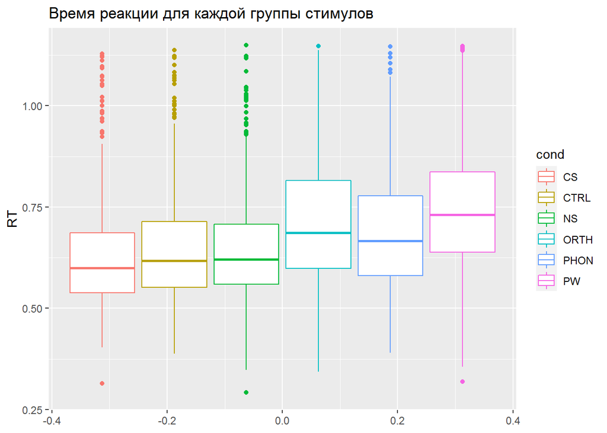

```r
ggplot(data = clean_data, aes(y = RT, group = cond, color = cond))+
  geom_boxplot()+
  labs(title = 'Время реакции для каждой группы стимулов')
```

## Соединение таблиц

```r
one_data <- merge(clean_data, word_info)
big_data <- one_data %>%
  select(cond, RT, correct:prime_freqlg)
```

# Анализ

```r
ic <- big_data %>%
  group_by(cond) %>%
  summarise(n=n(),
            mean = mean(RT),
            sd=sd(RT)) %>%
            mutate( se=sd/sqrt(n))  %>%
          mutate( ic=se * qt(.95, n-1))
```

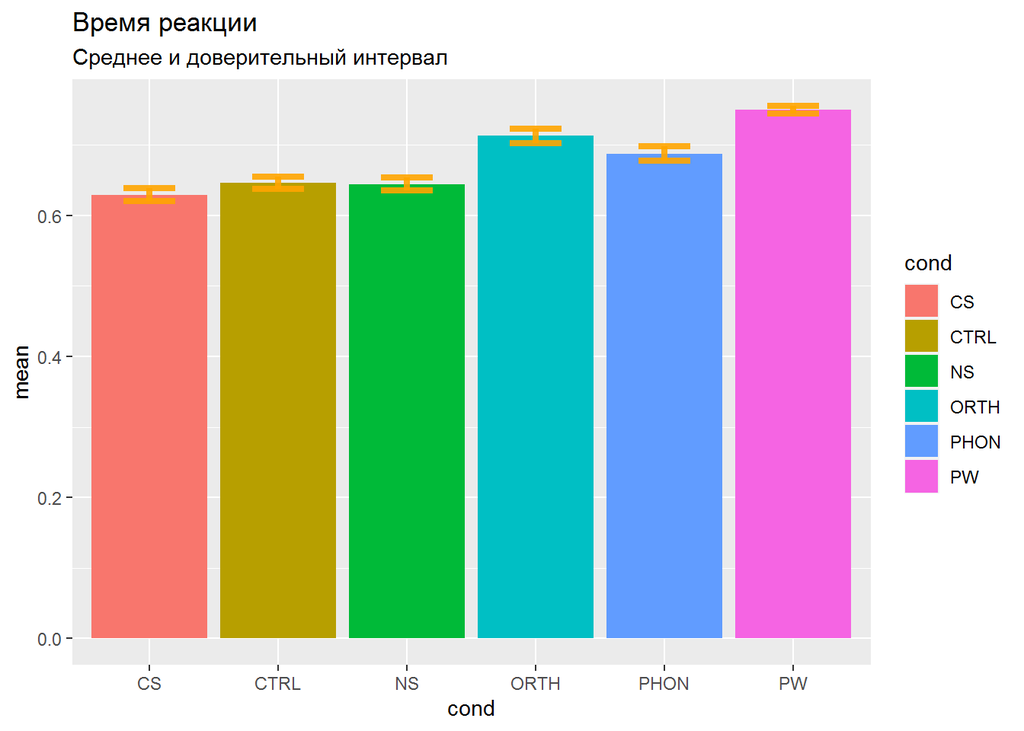

```r
ggplot(ic) +
  geom_bar( aes(x=cond, y=mean, fill = cond), stat="identity") +
  geom_errorbar( aes(x=cond, ymin=mean-ic, ymax=mean+ic), width=0.4, colour="orange", alpha=0.9, size=1.5) +
  labs(title = "Время реакции",
       subtitle = "Среднее и доверительный интервал")
```

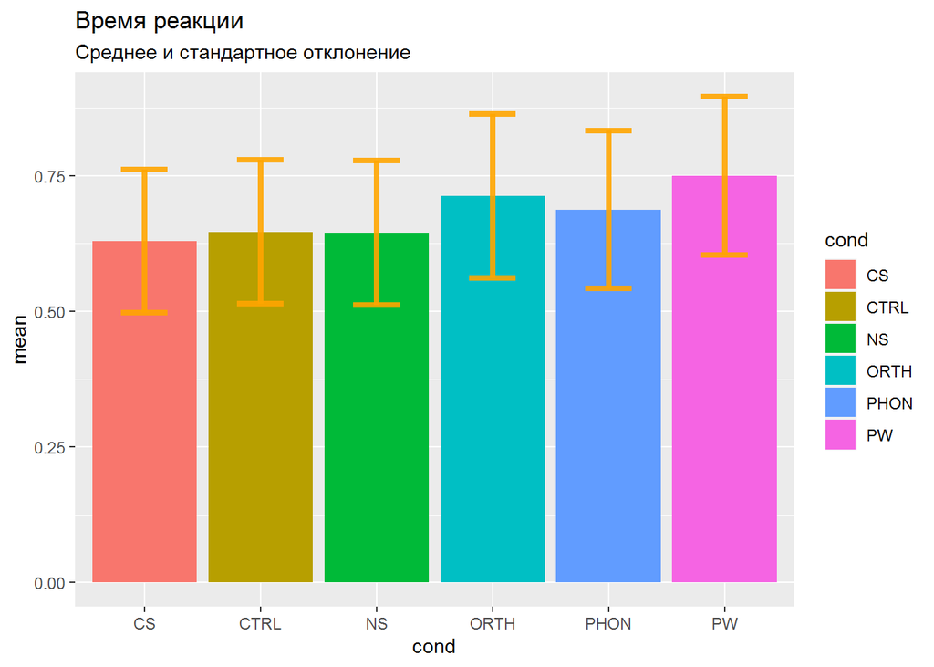

```r
ggplot(ic) +
  geom_bar( aes(x=cond, y=mean, fill = cond), stat="identity") +
  geom_errorbar( aes(x=cond, ymin=mean-sd, ymax=mean+sd), width=0.4, colour="orange", alpha=0.9, size=1.5) +
    labs(title = "Время реакции",
       subtitle = "Среднее и стандартное отклонение")
```

```r
acc <- big_data %>%
  group_by(cond) %>%
  summarise(n=n(),
            mean = mean(correct),
            sd=sd(correct)) %>%
            mutate( se=sd/sqrt(n))  %>%
          mutate( ic=se * qt(.95, n-1))
```

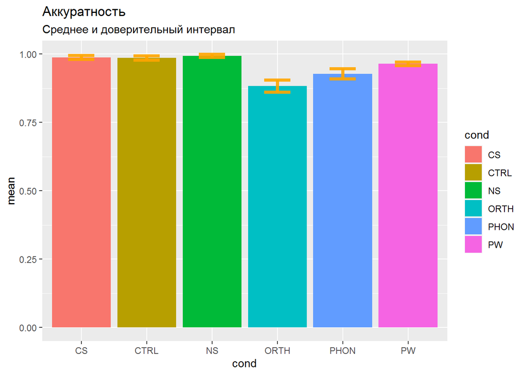

```r
ggplot(acc) +
  geom_bar( aes(x=cond, y=mean, fill = cond), stat="identity") +
  geom_errorbar( aes(x=cond, ymin=mean-ic, ymax=mean+ic), width=0.4, colour="orange", alpha=0.9, size=1.5) +
  labs(title = "Аккуратность",
       subtitle = "Среднее и доверительный интервал")
```

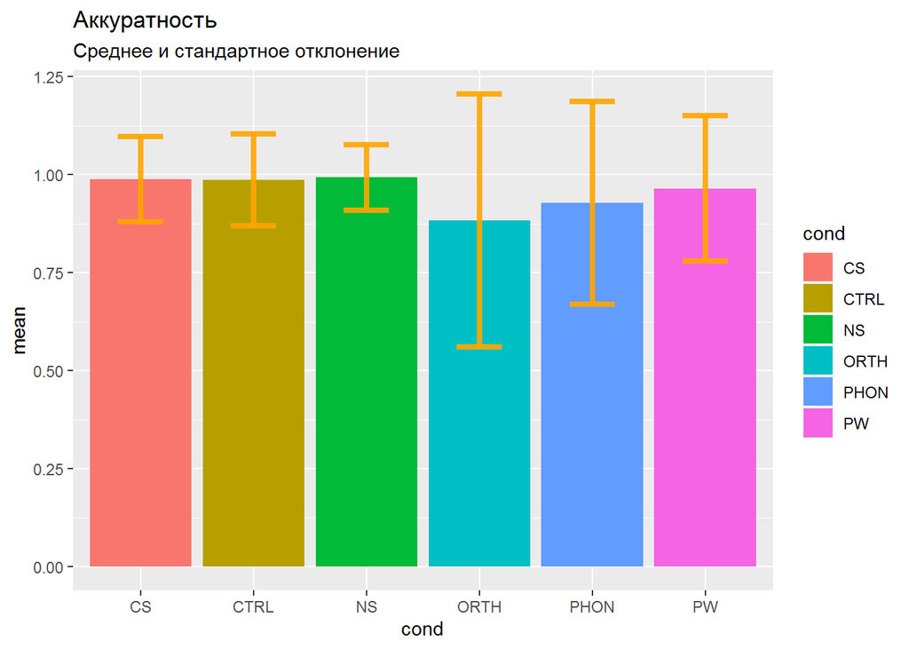

```r
ggplot(acc) +
  geom_bar( aes(x=cond, y=mean, fill = cond), stat="identity") +
  geom_errorbar( aes(x=cond, ymin=mean-sd, ymax=mean+sd), width=0.4, colour="orange", alpha=0.9, size=1.5) +
    labs(title = "Аккуратность",
       subtitle = "Среднее и стандартное отклонение")
```

```r
t.test(big_data$RT)
```

```
##
##  One Sample t-test
##
## data:  big_data$RT
## t = 330.81, df = 5015, p-value < 2.2e-16
## alternative hypothesis: true mean is not equal to 0
## 95 percent confidence interval:
##  0.6965779 0.7048831
## sample estimates:
## mean of x
## 0.7007305
```

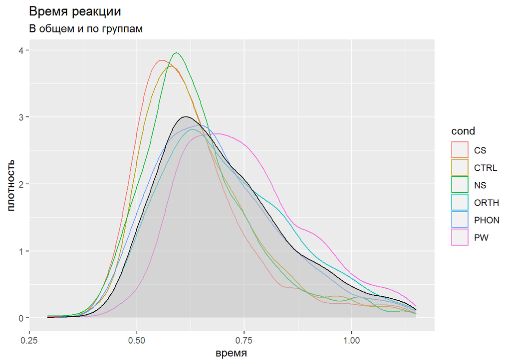

```r
ggplot(big_data)+
  geom_density(aes(x = RT, color = cond))+
  geom_density(aes(x = RT), fill = 'grey', alpha = 0.5)+
  labs(title = "Время реакции",
       subtitle = "В общем и по группам",
       x = 'время',
       y = 'плотность')
```

## ANOVA

```r
anova(lm(big_data$RT ~ big_data$cond))
```

```
## Analysis of Variance Table
##
## Response: big_data$RT
##                 Df  Sum Sq Mean Sq F value    Pr(>F)
## big_data$cond    5  11.875 2.37504  117.82 < 2.2e-16 ***
## Residuals     5010 100.991 0.02016
## ---
## Signif. codes:  0 '***' 0.001 '**' 0.01 '*' 0.05 '.' 0.1 ' ' 1
```

Между группами стимулов есть значимые различия во времени реакции: **p-value** намного меньше, чем 0,05.

```r
pairwise.t.test( x = big_data$RT,
                 g = big_data$cond,
                 p.adjust.method = "bonferroni")
```

```
##
##  Pairwise comparisons using t tests with pooled SD
##
## data:  big_data$RT and big_data$cond
##
##      CS      CTRL    NS      ORTH    PHON
## CTRL 0.646   -       -       -       -
## NS   1.000   1.000   -       -       -
## ORTH < 2e-16 5.1e-14 9.9e-15 -       -
## PHON 6.7e-11 1.4e-05 4.7e-06 0.049   -
## PW   < 2e-16 < 2e-16 < 2e-16 5.4e-07 < 2e-16
##
## P value adjustment method: bonferroni
```

А именно, при **попарном сравнении** от всех групп отличается группы `ORTH`, `PHON`, `PW`.

```r
my_anova <- aov(big_data$RT ~ big_data$cond)
my_anova_residuals <- residuals (object = my_anova)
ad.test(my_anova_residuals)
```

```
##
##  Anderson-Darling normality test
##
## data:  my_anova_residuals
## A = 53.28, p-value < 2.2e-16
```

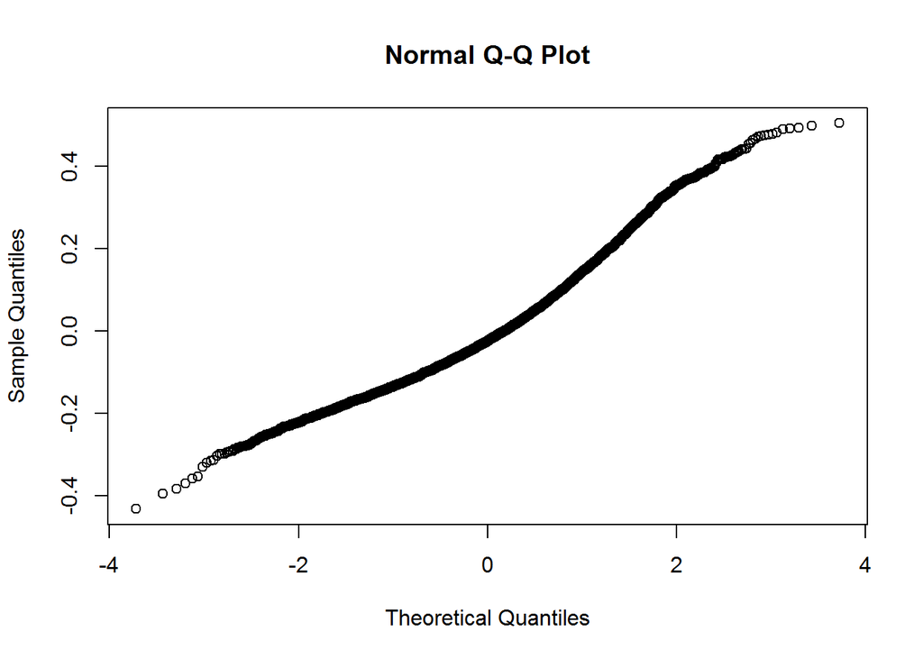

```r
qqnorm( y = my_anova_residuals )
```

```r
anova(lm(big_data$correct ~ big_data$cond))
```

```
## Analysis of Variance Table
##
## Response: big_data$correct
##                 Df  Sum Sq Mean Sq F value    Pr(>F)
## big_data$cond    5   5.435 1.08706  28.903 < 2.2e-16 ***
## Residuals     5010 188.430 0.03761
## ---
## Signif. codes:  0 '***' 0.001 '**' 0.01 '*' 0.05 '.' 0.1 ' ' 1
```

Между группами стимулов есть значимые различия в аккуратности: **p-value** намного меньше, чем 0,05.

```r
pairwise.t.test( x = big_data$correct,
                 g = big_data$cond,
                 p.adjust.method = "bonferroni")
```

```
##
##  Pairwise comparisons using t tests with pooled SD
##
## data:  big_data$correct and big_data$cond
##
##      CS      CTRL    NS      ORTH    PHON
## CTRL 1.0000  -       -       -       -
## NS   1.0000  1.0000  -       -       -
## ORTH < 2e-16 < 2e-16 < 2e-16 -       -
## PHON 2.6e-06 7.1e-06 2.8e-07 0.0016  -
## PW   0.1327  0.2550  0.0257  < 2e-16 0.0012
##
## P value adjustment method: bonferroni
```

А именно, при **попарном сравнении** от всех групп отличается группы `ORTH` и `PHON`.

```r
my_anova <- aov(big_data$RT ~ big_data$cond)
my_anova_residuals <- residuals (object = my_anova)
ad.test(my_anova_residuals)
```

```
##
##  Anderson-Darling normality test
##
## data:  my_anova_residuals
## A = 53.28, p-value < 2.2e-16
```

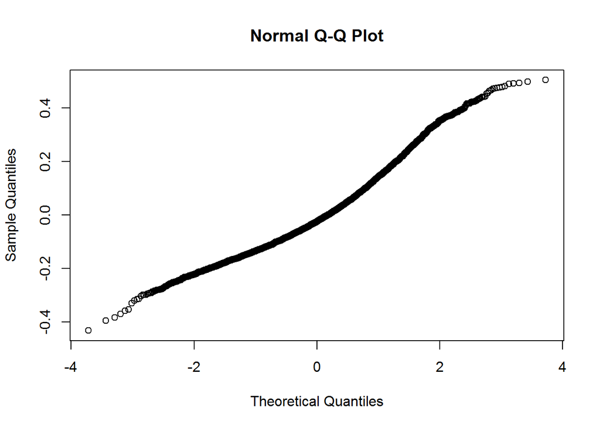

```r
qqnorm( y = my_anova_residuals )
```

```r
anova(lm(big_data$RT ~ big_data$word_freq))
```

```
## Analysis of Variance Table
##
## Response: big_data$RT
##                      Df  Sum Sq Mean Sq F value    Pr(>F)
## big_data$word_freq    1   6.486  6.4864  305.72 < 2.2e-16 ***
## Residuals          5014 106.380  0.0212
## ---
## Signif. codes:  0 '***' 0.001 '**' 0.01 '*' 0.05 '.' 0.1 ' ' 1
```

```r
pairwise.t.test( x = big_data$RT,
                 g = big_data$word_len,
                 p.adjust.method = "bonferroni")
```

```
##
##  Pairwise comparisons using t tests with pooled SD
##
## data:  big_data$RT and big_data$word_len
##
##   4       5       6       7
## 5 0.08322 -       -       -
## 6 3.3e-15 3.3e-08 -       -
## 7 0.00036 0.31654 0.07244 -
## 8 6.5e-08 9.6e-05 1.00000 0.07503
##
## P value adjustment method: bonferroni
```

```r
null.model <- lm(RT ~ 1, big_data ) # intercept only

step(object = null.model, # start with null.model
     direction = "forward", # only consider "addition" moves
     scope = RT ~ cond + word_freq + word_len + correct # largest model allowed
)
```

```
## Start:  AIC=-19029.64
## RT ~ 1
##
##             Df Sum of Sq    RSS    AIC
## + cond       5   11.8752 100.99 -19577
## + word_freq  1    6.4864 106.38 -19325
## + word_len   1    1.4283 111.44 -19092
## + correct    1    0.0566 112.81 -19030
## <none>                   112.87 -19030
##
## Step:  AIC=-19577.28
## RT ~ cond
##
##             Df Sum of Sq    RSS    AIC
## + word_freq  1   0.46967 100.52 -19599
## + word_len   1   0.30767 100.68 -19591
## + correct    1   0.20330 100.79 -19585
## <none>                   100.99 -19577
##
## Step:  AIC=-19598.66
## RT ~ cond + word_freq
##
##            Df Sum of Sq    RSS    AIC
## + word_len  1   0.26133 100.26 -19610
## + correct   1   0.21952 100.30 -19608
## <none>                  100.52 -19599
##
## Step:  AIC=-19609.72
## RT ~ cond + word_freq + word_len
##
##           Df Sum of Sq    RSS    AIC
## + correct  1   0.19375 100.07 -19617
## <none>                 100.26 -19610
##
## Step:  AIC=-19617.42
## RT ~ cond + word_freq + word_len + correct
```

```
##
## Call:
## lm(formula = RT ~ cond + word_freq + word_len + correct, data = big_data)
##
## Coefficients:
## (Intercept)     condCTRL       condNS     condORTH     condPHON       condPW
##   5.867e-01   -6.303e-04    1.278e-02    6.750e-02    4.535e-02    9.551e-02
##   word_freq     word_len      correct
##  -7.818e-05    6.445e-03    3.213e-02
```

```r
model <- lm(formula = RT ~ cond + word_freq + word_len + correct, data = big_data)
summary(model)
```

```
##
## Call:
## lm(formula = RT ~ cond + word_freq + word_len + correct, data = big_data)
##
## Residuals:
##      Min       1Q   Median       3Q      Max
## -0.39125 -0.10181 -0.02315  0.07960  0.54983
##
## Coefficients:
##               Estimate Std. Error t value Pr(>|t|)
## (Intercept)  5.867e-01  1.586e-02  36.992  < 2e-16 ***
## condCTRL    -6.303e-04  8.848e-03  -0.071 0.943215
## condNS       1.278e-02  8.659e-03   1.476 0.139972
## condORTH     6.750e-02  9.437e-03   7.152 9.78e-13 ***
## condPHON     4.535e-02  9.328e-03   4.862 1.20e-06 ***
## condPW       9.551e-02  8.209e-03  11.635  < 2e-16 ***
## word_freq   -7.818e-05  1.667e-05  -4.691 2.79e-06 ***
## word_len     6.445e-03  1.877e-03   3.433 0.000601 ***
## correct      3.213e-02  1.032e-02   3.114 0.001858 **
## ---
## Signif. codes:  0 '***' 0.001 '**' 0.01 '*' 0.05 '.' 0.1 ' ' 1
##
## Residual standard error: 0.1414 on 5007 degrees of freedom
## Multiple R-squared:  0.1134, Adjusted R-squared:  0.112
## F-statistic: 80.06 on 8 and 5007 DF,  p-value: < 2.2e-16
```